# STAT 184 Final Project

2023-12-02

**Background Information:**  
The primary dataset offers an avenue to analyze and gain valuable insights from the luminaries of the platform, including comprehensive details on top creators’ subscriber counts, video views, upload frequency, country of origin, earnings, and more.  
The primary dataset come from [here](https://www.kaggle.com/datasets/nelgiriyewithana/global-youtube-statistics-2023)

*Research Question:* where are Youtuber channels most popular in the world, and does their internet speed play a role?

**Data Access:**

```r
# Loading primary data
GlobalYouTube <- read.csv("https://raw.githubusercontent.com/Cassiebxy/STAT-184-Final-Project/main/Global%20YouTube%20Statistics.csv")

library(ggplot2)
library(DataComputing)
library(tidyverse)
library(esquisse)
library(mosaic)
# Secondary Data
library(Lock5Data)

head(GlobalYouTube)
```

|  | rank | Youtuber | subscribers | video.views | category | Title | uploads | Country | Abbreviation | channel_type | video_views_rank | country_rank | channel_type_rank | video_views_for_the_last_30_days | lowest_monthly_earnings | highest_monthly_earnings | lowest_yearly_earnings | highest_yearly_earnings | subscribers_for_last_30_days | created_year | created_month | created_date | Gross.tertiary.education.enrollment.... | Population | Unemployment.rate | Urban_population | Latitude | Longitude |
| --- | --- | --- | --- | --- | --- | --- | --- | --- | --- | --- | --- | --- | --- | --- | --- | --- | --- | --- | --- | --- | --- | --- | --- | --- | --- | --- | --- | --- |
| 1 | 1 | T-Series | 245000000 | 228000000000 | Music | T-Series | 20082 | India | IN | Music | 1 | 1 | 1 | 2.258e+09 | 564600 | 9.0e+06 | 6.8e+06 | 1.084e+08 | 2e+06 | 2006 | Mar | 13 | 28.1 | 1366417754 | 5.36 | 471031528 | 20.59368 | 78.96288 |
| 2 | 2 | YouTube Movies | 170000000 | 0 | Film & Animation | youtubemovies | 1 | United States | US | Games | 4055159 | 7670 | 7423 | 1.200e+01 | 0 | 5.0e-02 | 4.0e-02 | 5.800e-01 | NaN | 2006 | Mar | 5 | 88.2 | 328239523 | 14.70 | 270663028 | 37.09024 | -95.71289 |
| 3 | 3 | MrBeast | 166000000 | 28368841870 | Entertainment | MrBeast | 741 | United States | US | Entertainment | 48 | 1 | 1 | 1.348e+09 | 337000 | 5.4e+06 | 4.0e+06 | 6.470e+07 | 8e+06 | 2012 | Feb | 20 | 88.2 | 328239523 | 14.70 | 270663028 | 37.09024 | -95.71289 |
| 4 | 4 | Cocomelon - Nursery Rhymes | 162000000 | 164000000000 | Education | Cocomelon - Nursery Rhymes | 966 | United States | US | Education | 2 | 2 | 1 | 1.975e+09 | 493800 | 7.9e+06 | 5.9e+06 | 9.480e+07 | 1e+06 | 2006 | Sep | 1 | 88.2 | 328239523 | 14.70 | 270663028 | 37.09024 | -95.71289 |
| 5 | 5 | SET India | 159000000 | 148000000000 | Shows | SET India | 116536 | India | IN | Entertainment | 3 | 2 | 2 | 1.824e+09 | 455900 | 7.3e+06 | 5.5e+06 | 8.750e+07 | 1e+06 | 2006 | Sep | 20 | 28.1 | 1366417754 | 5.36 | 471031528 | 20.59368 | 78.96288 |
| 6 | 6 | Music | 119000000 | 0 | nan | Music | 0 | nan | nan | Music | 4057944 | NaN | NaN | NaN | 0 | 0.0e+00 | 0.0e+00 | 0.000e+00 | NaN | 2013 | Sep | 24 | NaN | NaN | NaN | NaN | NaN | NaN |

```r
head(GlobalInternet2019)
```

|  | Country | InternetSpeed | HoursOnline |
| --- | --- | --- | --- |
| 1 | Swizerland | 38.85 | 4.97 |
| 2 | United States | 32.89 | 6.52 |
| 3 | Germany | 24.64 | 4.62 |
| 4 | Australia | 16.36 | 5.07 |
| 5 | United Kingdom | 22.37 | 5.77 |
| 6 | France | 30.44 | 4.63 |

**Data Wrangling:**

```r
#ranking the popularity of countries, based on the amount of views they recieve. The highest number is the most popular.
popular<-
  GlobalYouTube %>%
  group_by(Country) %>%
  summarise(views = sum(video.views)) %>%
  mutate(the_rank = rank(views)) %>%
  arrange(desc(the_rank))
popular
```

| Country | views | the_rank |
| --- | --- | --- |
| United States | 3.690292e+12 | 50 |
| India | 2.281048e+12 | 49 |
| nan | 1.185152e+12 | 48 |
| Brazil | 4.812090e+11 | 47 |
| United Kingdom | 4.305665e+11 | 46 |
| Thailand | 2.643180e+11 | 45 |
| Russia | 2.329963e+11 | 44 |
| South Korea | 2.255917e+11 | 43 |
| Mexico | 1.982199e+11 | 42 |
| Argentina | 1.944154e+11 | 41 |

[output cut: 40 more lines]

```r
# ranking the internet speed of countries, the highest number is the highest speed.
internetspeed <-
  GlobalInternet2019 %>%
  group_by(Country) %>%
  summarise(speed = sum(InternetSpeed)) %>%
  mutate(rank = rank(speed)) %>%
  arrange(desc(rank))
internetspeed
```

| Country | speed | rank |
| --- | --- | --- |
| Swizerland | 38.85 | 9 |
| Spain | 36.06 | 8 |
| United States | 32.89 | 7 |
| France | 30.44 | 6 |
| Germany | 24.64 | 5 |
| United Kingdom | 22.37 | 4 |
| Italy | 17.30 | 3 |
| Australia | 16.36 | 2 |
| Brazil | 4.84 | 1 |

```r
NA
```

```r
# joining the data tables by the country's video views and internet speed
countryspeeds <-
  GlobalInternet2019 %>%
  select(Country, InternetSpeed) %>%
  left_join(GlobalYouTube %>% select(Country, video.views, rank),
            by = c("Country" = "Country"))
countryspeeds
```

| Country | InternetSpeed | video.views | rank |
| --- | --- | --- | --- |
| Swizerland | 38.85 | NA | NA |
| United States | 32.89 | 0 | 2 |
| United States | 32.89 | 28368841870 | 3 |
| United States | 32.89 | 164000000000 | 4 |
| United States | 32.89 | 93247040539 | 7 |
| United States | 32.89 | 77180169894 | 10 |
| United States | 32.89 | 77428473662 | 12 |
| United States | 32.89 | 0 | 19 |
| United States | 32.89 | 38843229963 | 23 |
| United States | 32.89 | 16241549158 | 29 |

[output cut: 453 more lines]

```r
NA
```

```r
# Wrangling, E
data("GlobalInternet2019")
GlobalInternet2019$InternetSpeed1 <- round(GlobalInternet2019$InternetSpeed)
GlobalInternet2019 <-
  GlobalInternet2019 %>%
  select(Country, InternetSpeed1, HoursOnline) %>%
  rename(InternetSpeed = InternetSpeed1)
GlobalInternet2019
```

| Country | InternetSpeed | HoursOnline |
| --- | --- | --- |
| Swizerland | 39 | 4.97 |
| United States | 33 | 6.52 |
| Germany | 25 | 4.62 |
| Australia | 16 | 5.07 |
| United Kingdom | 22 | 5.77 |
| France | 30 | 4.63 |
| Spain | 36 | 4.30 |
| Italy | 17 | 6.07 |
| Brazil | 5 | 9.29 |

```r
# Wrangling, C
narrow_table <-
  GlobalYouTube %>%
  #mutate(popularity = video.views + subscribers) %>%
  pivot_longer(
    cols = c(`subscribers`, `video.views`),  #names of columns we want to become a new variable
    names_to = "popularity.category",         #what you want to call the new column of the data in the line above
    values_to = "popularity"    #what you want to call the variable that stores the values
  )

narrow_table
```

| rank | Youtuber | category | Title | uploads | Country | Abbreviation | channel_type | video_views_rank | country_rank | channel_type_rank | video_views_for_the_last_30_days | lowest_monthly_earnings | highest_monthly_earnings | lowest_yearly_earnings | highest_yearly_earnings | subscribers_for_last_30_days | created_year | created_month | created_date | Gross.tertiary.education.enrollment.... | Population | Unemployment.rate | Urban_population | Latitude | Longitude | popularity.category | popularity |
| --- | --- | --- | --- | --- | --- | --- | --- | --- | --- | --- | --- | --- | --- | --- | --- | --- | --- | --- | --- | --- | --- | --- | --- | --- | --- | --- | --- |
| 1 | T-Series | Music | T-Series | 20082 | India | IN | Music | 1 | 1 | 1 | 2258000000 | 564600.00 | 9.000e+06 | 6.800e+06 | 1.084e+08 | 2000000 | 2006 | Mar | 13 | 28.1 | 1366417754 | 5.36 | 471031528 | 20.593684 | 78.962880 | subscribers | 245000000 |
| 1 | T-Series | Music | T-Series | 20082 | India | IN | Music | 1 | 1 | 1 | 2258000000 | 564600.00 | 9.000e+06 | 6.800e+06 | 1.084e+08 | 2000000 | 2006 | Mar | 13 | 28.1 | 1366417754 | 5.36 | 471031528 | 20.593684 | 78.962880 | video.views | 228000000000 |
| 2 | YouTube Movies | Film & Animation | youtubemovies | 1 | United States | US | Games | 4055159 | 7670 | 7423 | 12 | 0.00 | 5.000e-02 | 4.000e-02 | 5.800e-01 | NaN | 2006 | Mar | 5 | 88.2 | 328239523 | 14.70 | 270663028 | 37.090240 | -95.712891 | subscribers | 170000000 |
| 2 | YouTube Movies | Film & Animation | youtubemovies | 1 | United States | US | Games | 4055159 | 7670 | 7423 | 12 | 0.00 | 5.000e-02 | 4.000e-02 | 5.800e-01 | NaN | 2006 | Mar | 5 | 88.2 | 328239523 | 14.70 | 270663028 | 37.090240 | -95.712891 | video.views | 0 |
| 3 | MrBeast | Entertainment | MrBeast | 741 | United States | US | Entertainment | 48 | 1 | 1 | 1348000000 | 337000.00 | 5.400e+06 | 4.000e+06 | 6.470e+07 | 8000000 | 2012 | Feb | 20 | 88.2 | 328239523 | 14.70 | 270663028 | 37.090240 | -95.712891 | subscribers | 166000000 |
| 3 | MrBeast | Entertainment | MrBeast | 741 | United States | US | Entertainment | 48 | 1 | 1 | 1348000000 | 337000.00 | 5.400e+06 | 4.000e+06 | 6.470e+07 | 8000000 | 2012 | Feb | 20 | 88.2 | 328239523 | 14.70 | 270663028 | 37.090240 | -95.712891 | video.views | 28368841870 |
| 4 | Cocomelon - Nursery Rhymes | Education | Cocomelon - Nursery Rhymes | 966 | United States | US | Education | 2 | 2 | 1 | 1975000000 | 493800.00 | 7.900e+06 | 5.900e+06 | 9.480e+07 | 1000000 | 2006 | Sep | 1 | 88.2 | 328239523 | 14.70 | 270663028 | 37.090240 | -95.712891 | subscribers | 162000000 |
| 4 | Cocomelon - Nursery Rhymes | Education | Cocomelon - Nursery Rhymes | 966 | United States | US | Education | 2 | 2 | 1 | 1975000000 | 493800.00 | 7.900e+06 | 5.900e+06 | 9.480e+07 | 1000000 | 2006 | Sep | 1 | 88.2 | 328239523 | 14.70 | 270663028 | 37.090240 | -95.712891 | video.views | 164000000000 |
| 5 | SET India | Shows | SET India | 116536 | India | IN | Entertainment | 3 | 2 | 2 | 1824000000 | 455900.00 | 7.300e+06 | 5.500e+06 | 8.750e+07 | 1000000 | 2006 | Sep | 20 | 28.1 | 1366417754 | 5.36 | 471031528 | 20.593684 | 78.962880 | subscribers | 159000000 |
| 5 | SET India | Shows | SET India | 116536 | India | IN | Entertainment | 3 | 2 | 2 | 1824000000 | 455900.00 | 7.300e+06 | 5.500e+06 | 8.750e+07 | 1000000 | 2006 | Sep | 20 | 28.1 | 1366417754 | 5.36 | 471031528 | 20.593684 | 78.962880 | video.views | 148000000000 |

[output cut: 990 more lines]

**Data EDA:**

EDA for the primary dataset:

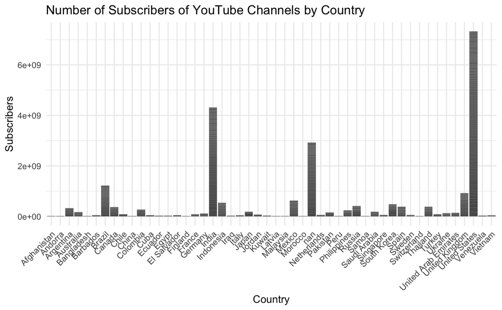

```r
GlobalYouTube %>%
  ggplot(aes(x = Country, y = subscribers)) +
  geom_bar(stat = "identity") +
  labs(title = "Number of Subscribers of YouTube Channels by Country", x = "Country", y = "Subscribers") +
  theme_minimal() +
  theme(axis.text.x = element_text(angle = 45, hjust = 1))
```

EDA for the secondary dataset:

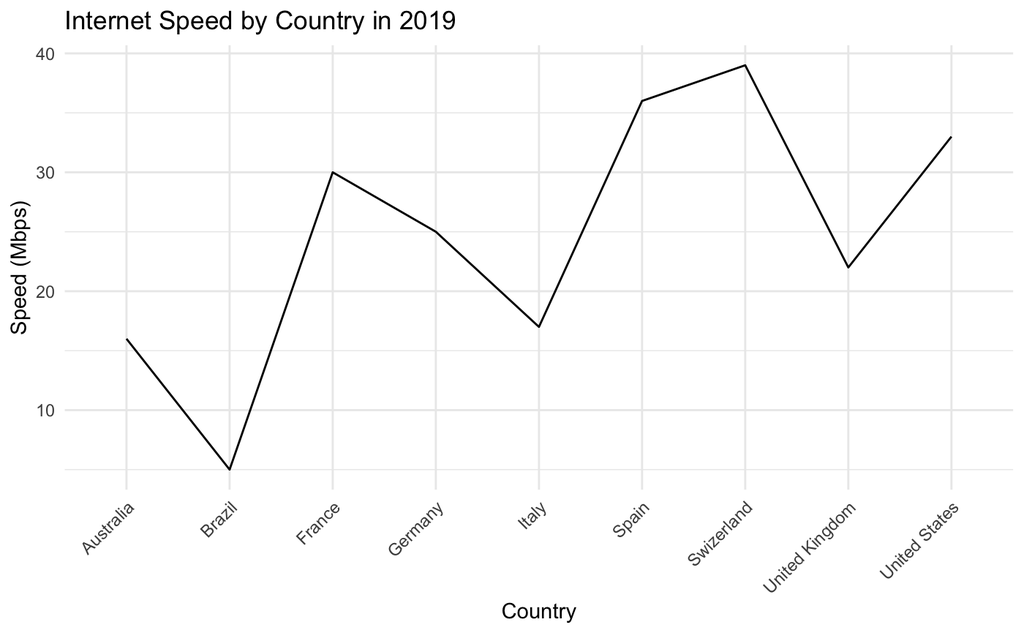

```r
GlobalInternet2019 %>%
  ggplot(aes(x = Country, y = InternetSpeed)) +
  geom_line(group = 1) +
  labs(title = "Internet Speed by Country in 2019", x = "Country", y = "Speed (Mbps)") +
  theme_minimal() +
  theme(axis.text.x = element_text(angle = 45, hjust = 1))
```

**Machine Learning**

The clustering and visualization of YouTube channels created between 2010 and 2023 with subscribers above the average value

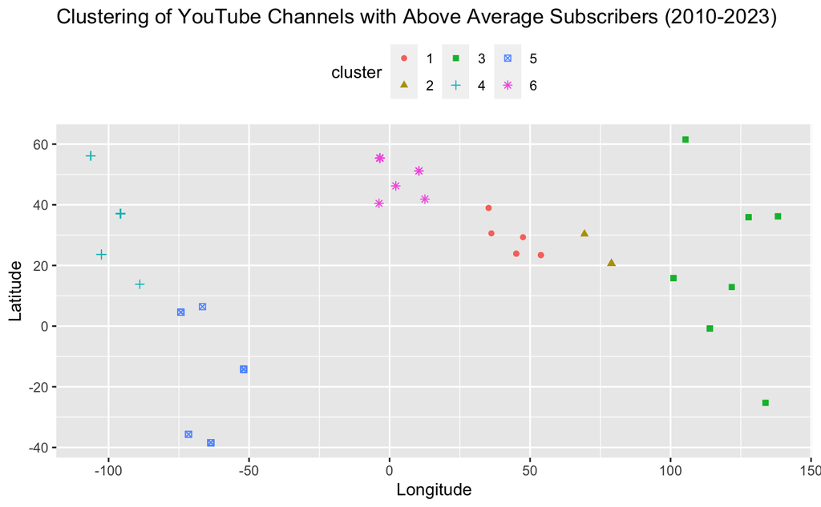

```r
library(dplyr)

# Filter for channels created between 2010 and 2023
YouTubeChannels2010_2023 <- GlobalYouTube %>%
  filter(created_year >= 2010 & created_year <= 2023) %>%
  filter(!is.na(subscribers) & !is.na(Latitude) & !is.na(Longitude))

# Calculate the average number of subscribers for the filtered channels
average_subscribers <- mean(YouTubeChannels2010_2023$subscribers)

# Filter out channels with subscribers above the average
channels_above_average <- YouTubeChannels2010_2023 %>%
  filter(subscribers > average_subscribers)

# Perform k-means clustering on the channels above the average
set.seed(123)
clusters <- kmeans(channels_above_average[, c('Longitude', 'Latitude')], centers = 6)

# Add the cluster information to the dataframe
channels_above_average$cluster <- as.factor(clusters$cluster)

# Visualize the clusters
channels_above_average %>%
  ggplot(aes(x = Longitude, y = Latitude)) +
  geom_point(aes(color = cluster, shape = cluster)) +
  theme(legend.position = "top") +
  labs(title = "Clustering of YouTube Channels with Above Average Subscribers (2010-2023)")
```

**Data Visualization:**

```
Mapping API still under development and may change in future releases.
Warning: 1 items were not translated
```

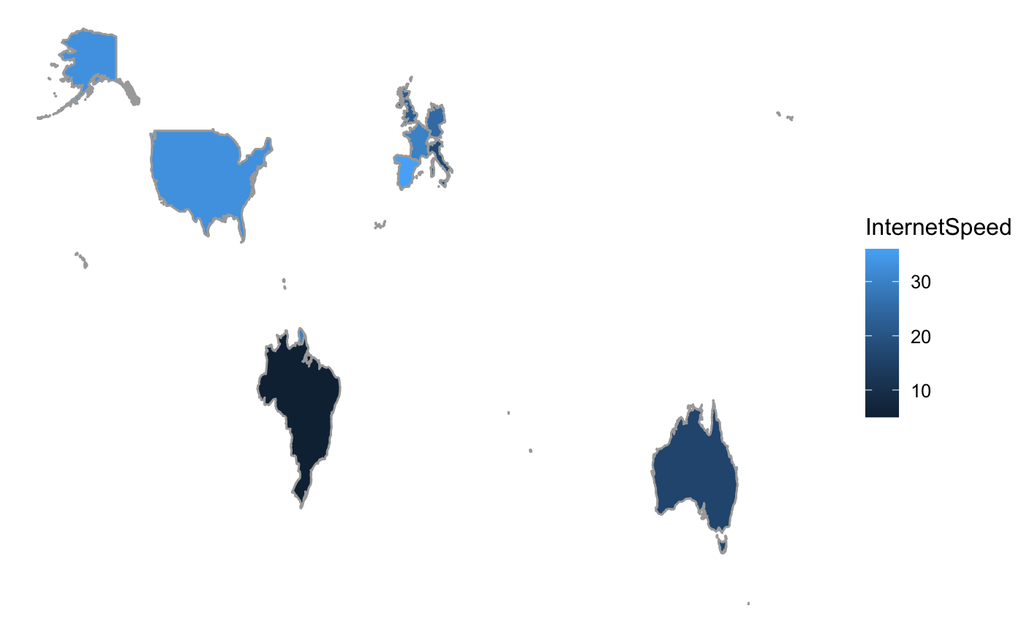

```r
# Visualizations, A
mWorldMap(GlobalInternet2019, key="Country", fill="InternetSpeed")
```

Visualize YouTube channels created between 2010 and 2023 based on their latitude and longitude

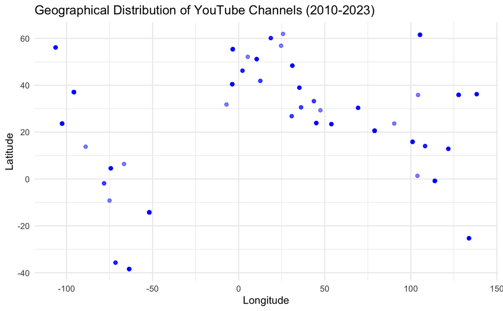

```r
filtered_channels <- GlobalYouTube %>%
  filter(created_year >= 2010, created_year <= 2023) %>%
  filter(!is.na(Latitude), !is.na(Longitude))

# Plotting
filtered_channels %>%
  ggplot(aes(x = Longitude, y = Latitude)) +
  geom_point(color = "blue", alpha = 0.5) +
  theme_minimal() +
  labs(title = "Geographical Distribution of YouTube Channels (2010-2023)",
       x = "Longitude",
       y = "Latitude")
```

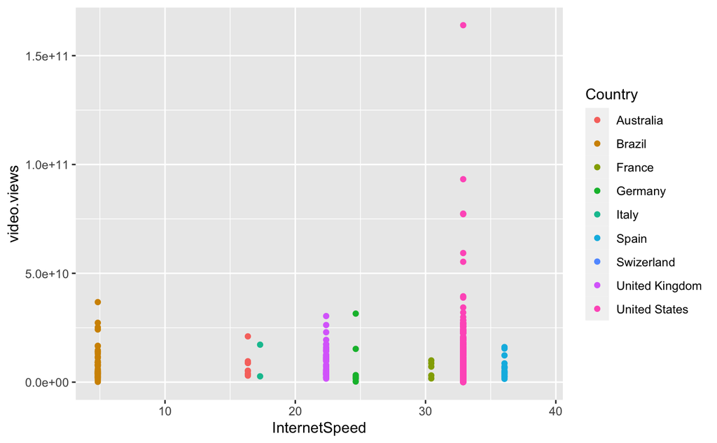

```r
countryspeeds %>%
  ggplot(aes(x = InternetSpeed, y = video.views))+
  geom_point()+
  aes(colour= Country)
```

World Map:

```r
# Install required packages if not already installed
if (!require("rnaturalearth")) install.packages("rnaturalearth")
```

```
Support for Spatial objects (`sp`) will be deprecated in {rnaturalearth} and will be removed in a future release of the package. Please use `sf` objects with {rnaturalearth}. For example: `ne_download(returnclass = 'sf')`
```

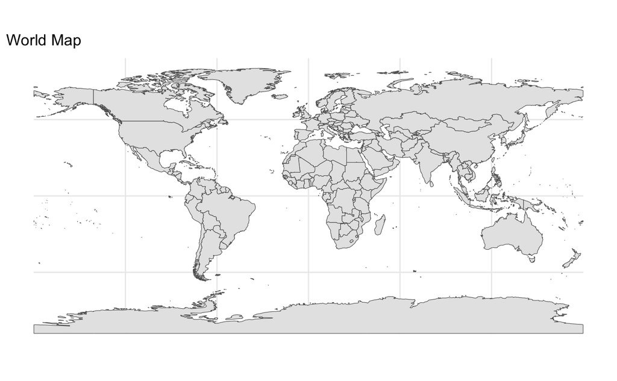

```r
if (!require("rnaturalearthdata")) install.packages("rnaturalearthdata")
library(rnaturalearth)
library(rnaturalearthdata)

world_map <- ne_countries(scale = "medium", returnclass = "sf")

# Plot the world map
world_map %>%
  ggplot() +
  geom_sf() +
  theme_minimal() +
  labs(title = "World Map") +
  theme(legend.position = "none")
```

Overlay the top 5 countries with the fastest internet speeds from the GlobalInternet2019 dataset onto your world map

```r
# Sort by internet speed and create a rank column
GlobalInternet2019$InternetSpeedRank <- rank(-GlobalInternet2019$InternetSpeed, ties.method = "first")

# Identifying the top 5 countries
Top5InternetSpeed <- GlobalInternet2019 %>%
  arrange(desc(InternetSpeed)) %>%
  head(5)

Top5InternetSpeed
```

|  | Country | InternetSpeed | HoursOnline | InternetSpeedRank |
| --- | --- | --- | --- | --- |
| 1 | Swizerland | 39 | 4.97 | 1 |
| 2 | Spain | 36 | 4.30 | 2 |
| 3 | United States | 33 | 6.52 | 3 |
| 4 | France | 30 | 4.63 | 4 |
| 5 | Germany | 25 | 4.62 | 5 |

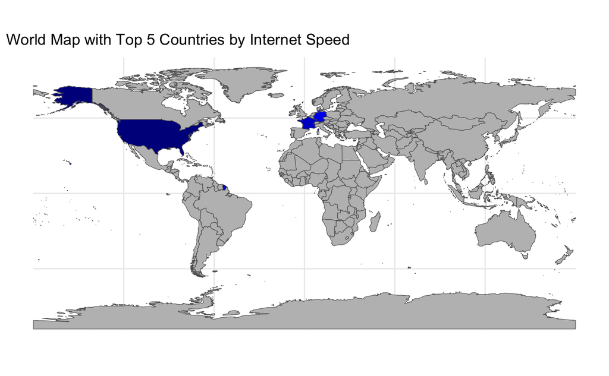

```r
# Merge the world data with the Top5InternetSpeed data
world_with_speed <- merge(world_map, Top5InternetSpeed, by.x = "name_long", by.y = "Country", all.x = TRUE)

# Plot
ggplot(data = world_with_speed) +
  geom_sf(aes(fill = factor(InternetSpeedRank))) +
  scale_fill_manual(values = c("gray", "blue4", "blue3", "blue2", "blue1", "lightblue"),
                    na.value = "gray", guide = "none") +
  theme_minimal() +
  labs(title = "World Map with Top 5 Countries by Internet Speed") +
  theme(legend.position = "none")
```

Combine the visualization of the top 5 countries with the fastest internet speeds with the locations of YouTube channels created between 2010 and 2023

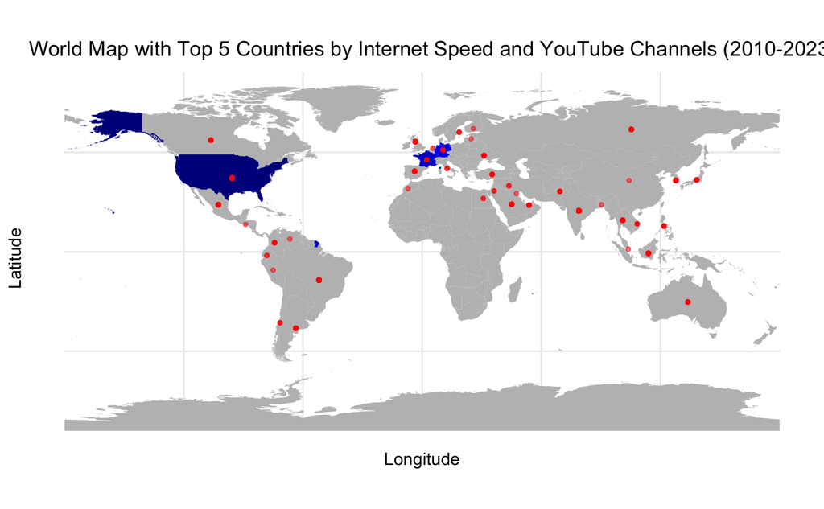

```r
# Filter for channels created between 2010 and 2023 and with valid coordinates
YouTubeChannels2010_2023 <- subset(GlobalYouTube, created_year >= 2010 & created_year <= 2023 &
                                   !is.na(Longitude) & !is.na(Latitude))

# Plot the world map with the top 5 countries highlighted and YouTube channel locations
ggplot() +
  geom_sf(data = world_with_speed, aes(fill = factor(InternetSpeedRank)), color = NA) +
  scale_fill_manual(values = c("gray", "blue4", "blue3", "blue2", "blue1", "lightblue"),
                    na.value = "gray", guide = "none") +
  geom_point(data = YouTubeChannels2010_2023, aes(x = Longitude, y = Latitude),
             color = "red", size = 1, alpha = 0.5) +
  theme_minimal() +
  labs(title = "World Map with Top 5 Countries by Internet Speed and YouTube Channels (2010-2023)") +
  theme(legend.position = "none")
```

```r
if (!require("sf")) install.packages("sf")
if (!require("lwgeom")) install.packages("lwgeom")
```

```
Linking to liblwgeom 3.0.0beta1 r16016, GEOS 3.11.0, PROJ 9.1.0
```

```r
library(sf)
library(lwgeom)

world_map <- ne_countries(scale = "medium", returnclass = "sf")

GlobalInternet2019$InternetSpeedRank <- rank(-GlobalInternet2019$InternetSpeed, ties.method = "first")
Top5InternetSpeed <- GlobalInternet2019 %>%
  filter(InternetSpeedRank <= 5)

world_with_speed <- world_map %>%
  left_join(Top5InternetSpeed, by = c("name_long" = "Country"))

GlobalYouTube <- GlobalYouTube %>%
  filter(!is.na(Longitude) & !is.na(Latitude))

GlobalYouTube_sf <- st_as_sf(GlobalYouTube, coords = c("Longitude", "Latitude"),
                             crs = st_crs(world_map))


world_with_speed <- world_with_speed %>%
  mutate(geometry = st_make_valid(geometry))

channels_in_top_countries <- st_join(GlobalYouTube_sf, world_with_speed, join = st_within)

top_countries_with_channels <- channels_in_top_countries %>%
  filter(!is.na(InternetSpeedRank)) %>%
  distinct(name_long) %>%
  pull(name_long)

top_countries_with_channels
```

```
[1] "United States" "Spain"         "Germany"       "France"
```

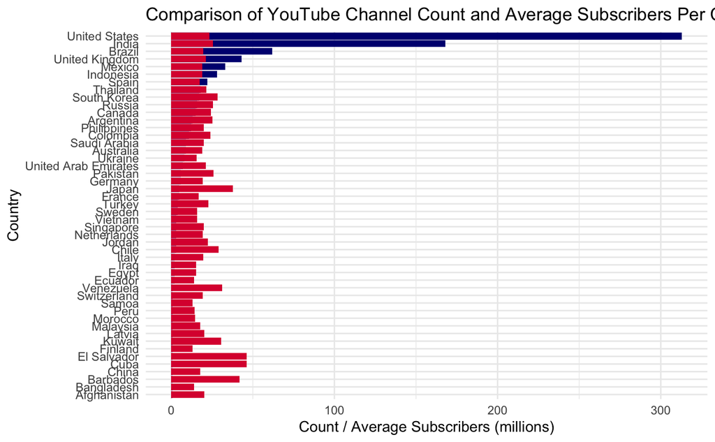

```r
youtube_data_grouped <- GlobalYouTube %>%
  group_by(Country) %>%
  summarize(Channel_Count = n(),
            Average_Subscribers = mean(subscribers, na.rm = TRUE))

youtube_data_grouped %>%
  ggplot(aes(x=reorder(Country, Channel_Count), y=Channel_Count)) +
  geom_col(fill="navy") +
  geom_col(aes(y=Average_Subscribers/1000000), fill="#DC143C") +
  theme_minimal() +
  labs(title="Comparison of YouTube Channel Count and Average Subscribers Per Country",
       x="Country", y="Count / Average Subscribers (millions)") +
  coord_flip()
```

**Linear Regression:**

To figure out the statistical relationship between the number of Global Youtubers’ subscribers and the Global Internet Speed, we decided to make a linear regression model to explain.

```r
merged_data <- merge(GlobalYouTube, GlobalInternet2019, by = "Country")
merged_data$sbscribers <- as.numeric(merged_data$subscribers)
merged_data$InternetSpeed <- as.numeric(merged_data$InternetSpeed)

model <- lm(subscribers ~ InternetSpeed, data = merged_data)

summary(model)
```

```
Call:
lm(formula = subscribers ~ InternetSpeed, data = merged_data)

Residuals:
      Min        1Q    Median        3Q       Max
-10768575  -7907426  -4557088   1267086 147179623

Coefficients:
              Estimate Std. Error t value Pr(>|t|)
(Intercept)   18990195    2297712   8.265 1.51e-15 ***
InternetSpeed   116066      77810   1.492    0.136
---
Signif. codes:  0 ‘***’ 0.001 ‘**’ 0.01 ‘*’ 0.05 ‘.’ 0.1 ‘ ’ 1

Residual standard error: 16540000 on 460 degrees of freedom
Multiple R-squared:  0.004814,  Adjusted R-squared:  0.00265
F-statistic: 2.225 on 1 and 460 DF,  p-value: 0.1365
```

**Analysis:**

The p-value for the Internet speed coefficient is 0.136, which is above common levels of significance, indicating that the effect of Internet speed on the number of YouTube subscribers is not statistically significant.

R-squared = 0.004814. This indicates that the Internet speed in the model explains a very low proportion (less than 0.5%) of the variation in the number of YouTube subscribers. In other words, the variation in the number of YouTube subscribers can hardly be explained by Internet speed.

Based on the results of this model, we can conclude that, there is no significant linear relationship between Internet speed and the number of YouTube subscribers. This may be due to the fact that subscriber numbers are influenced by a variety of factors that are not included in the current model.